# Practice Lab: Buenos Aires Subway - Sorting and filtering

You're continuing your exploration of the Buenos Aires Subway system and want to look at the busiest stations. You now have all passenger counts for all stations in the subway network, for all open hours for the month of March 2024. This will be *a lot* more information than before. Your analysis can help you recommend if a station will need more train cars to accommodate the traffic or how much resources are needed for crowd control.

[figure not shown]

## General instructions

- **Replace any instances of `None` with your own code**. All `None`s must be replaced.
- **Compare your results with the expected output** shown below the code.
- **Check the solution** using the expandable cell to verify your answer.

Happy coding!

**Important note**: Code blocks with None will not run properly. If you run them before completing the exercise, you will likely get an error.

- Step 1: Load and sort the dataset
- Step 2: Filter a subway line
- Step 3: Select rows
- Step 4: Filter rush hours

## Step 1: Load and sort the dataset

The cell below imports the CSV you will be working with. This data corresponds to the number of passengers at every station in the subway system of Buenos Aires in March 2024, with an hourly granularity. It consists of 5 features:

- `date`: date of the observation, in format YYYY-MM-DD
- `hour`: hour of the observation
- `station`: name of the subway station
- `line`: name of the subway line (A, B, C, D, E, H). Each line corresponds to one of the colored lines in the map above.
- `pax_TOTAL`: total number of passengers at the station

```python
# import pandas
import pandas as pd

# Load the data
df = pd.read_csv("march2024_pax_hourly.csv")

# Show the first few rows
df.sample(4)
```

|  | date | hour | station | line | pax_TOTAL |
| --- | --- | --- | --- | --- | --- |
| 4432 | 2024-03-04 | 9 | Constitucion | C | 6855 |
| 29194 | 2024-03-19 | 14 | Echeverria | B | 228 |
| 11321 | 2024-03-08 | 16 | Acoyte | A | 1027 |
| 5388 | 2024-03-04 | 21 | Carabobo | A | 100 |

You can use a function defined in the `helper_functions.py` file in your workspace to print the number of rows and unique stations in the DataFrame.

```python
import helper_functions

# Utility function for printing rows and stations
helper_functions.print_rows_stations(df)
```

```
number of rows: 49219

stations in this DataFrame:
['Acoyte' 'Aguero' 'Alberti' 'Angel Gallardo' 'Avenida La Plata'
 'Avenida de Mayo' 'Boedo' 'Bolivar' 'Callao.B' 'Carabobo' 'Carlos Gardel'
 'Carlos Pellegrini' 'Caseros' 'Castro Barros' 'Catalinas' 'Congreso'
 'Constitucion' 'Cordoba' 'Correo Central' 'Corrientes' 'Diagonal Norte'
 'Dorrego' 'Echeverria' 'Emilio Mitre' 'Entre Rios' 'Facultad de Derecho'
 'Federico Lacroze' 'Flores' 'Florida' 'General Belgrano'
 'General San Martin' 'Hospitales' 'Humberto I' 'Inclan' 'Independencia'
 'Independencia.H' 'Jose Maria Moreno' 'Jujuy' 'Las Heras' 'Lavalle'
 'Leandro N. Alem' 'Lima' 'Loria' 'Los Incas' 'Malabia' 'Mariano Moreno'
 'Medalla Milagrosa' 'Medrano' 'Ministro Carranza' 'Once' 'Pasco'
 'Pasteur' 'Patricios' 'Peru' 'Pichincha' 'Piedras' 'Plaza Italia'
 'Plaza Miserere' 'Plaza de Mayo' 'Primera Junta' 'Puan' 'Pueyrredon'
 'Pza. de los Virreyes' 'Retiro' 'Retiro E' 'Rio de Janeiro' 'Rosas'
 'Saenz Pena ' 'San Jose' 'San Juan' 'San Pedrito' 'Santa Fe' 'Tronador'
 'Urquiza' 'Uruguay' 'Varela' 'Venezuela' 'Catedral' 'Congreso de Tucuman'
 'Jose Hernandez' 'Palermo' 'Scalabrini Ortiz' 'Juramento' 'Pueyrredon.D'
 'Bulnes' 'Olleros' '9 de julio' 'Callao' 'Tribunales'
 'Facultad de Medicina']
```

Now that you've seen some characteristics of the dataset, you want to sort it by `line` and `pax_TOTAL` so you can analyze the busiest times in each subway line.

**▶▶▶ Directions**

1. Define a `columns` variable to hold the list of features that you want to sort the dataset by. These will be by `line` first, then `pax_TOTAL`.
2. Define an `order` variable to contain boolean values. These will specify if you will sort a feature in ascending order or not. You will sort `line` **ascending**, then `pax_TOTAL` **descending**.
3. Use the `sort_values()` method to sort the DataFrame by the columns in the orders you specified. Store the result in `df_sorted`

```python
### START CODE HERE ###

# Create a list of strings to hold two features: 'line' and 'pax_TOTAL'.
columns = ["line", "pax_TOTAL"]

# Create a list of booleans to specify the sorting order. 'line' is ascending, 'pax_TOTAL' is descending.
order = [True, False]

# Sort the dataframe by the columns and order you specified.
df_sorted = df.sort_values(by = columns, ascending = order)

### END CODE HERE ###

# Preview the results
df_sorted.head(5)
```

|  | date | hour | station | line | pax_TOTAL |
| --- | --- | --- | --- | --- | --- |
| 40234 | 2024-03-26 | 8 | San Pedrito | A | 4252 |
| 32079 | 2024-03-21 | 8 | San Pedrito | A | 4179 |
| 28713 | 2024-03-19 | 8 | San Pedrito | A | 4169 |
| 41920 | 2024-03-27 | 8 | San Pedrito | A | 4099 |
| 38548 | 2024-03-25 | 8 | San Pedrito | A | 4081 |

**Expected output:**

[figure not shown]

**Click here to see the solution**

Your solution should look something like this:

```
# Create a list of strings to hold two features: 'line' and 'pax_TOTAL'.
columns = ["line", "pax_TOTAL"]

# Create a list of booleans to specify the sorting order. 'line' is ascending, 'pax_TOTAL' is descending.
order = [True, False]

# Sort the dataframe by the columns and order you specified.
df_sorted = df.sort_values(by=columns, ascending=order)
```

## Step 2: Filter a subway line

Now that you have the sorted dataset. You can filter a subway line and it will return a sorted dataset by total passengers. For this exercise, you will filter line E.

**▶▶▶ Directions**

1. Filter `df_sorted` for data points that are in **line E**.

```python
# You can change this later if you want. You can choose from: [A, B, C, D, E, H].
line = 'E'

### START CODE HERE ###

# Filter `df_sorted` for rows that match the line specified
df_filter_line = df_sorted[df_sorted["line"] == line]

### END CODE HERE

helper_functions.print_rows_stations(df_filter_line)
```

```
number of rows: 10135

stations in this DataFrame:
['Independencia.H' 'Bolivar' 'Pza. de los Virreyes' 'Catalinas'
 'Correo Central' 'General Belgrano' 'Avenida La Plata' 'Emilio Mitre'
 'Jose Maria Moreno' 'Retiro E' 'Boedo' 'Urquiza' 'San Jose' 'Entre Rios'
 'Varela' 'Medalla Milagrosa' 'Pichincha' 'Jujuy']
```

**Expected output:**

```
number of rows: 10135

stations in this DataFrame:
['Independencia.H' 'Bolivar' 'Pza. de los Virreyes' 'Catalinas'
 'Correo Central' 'General Belgrano' 'Avenida La Plata' 'Emilio Mitre'
 'Jose Maria Moreno' 'Retiro E' 'Boedo' 'Urquiza' 'San Jose' 'Entre Rios'
 'Varela' 'Medalla Milagrosa' 'Pichincha' 'Jujuy']
```

**Click here to see the solution**

Your solution should look something like this:

```
# Filter `df_sorted` for rows that match the line specified
df_filter_line = df_sorted[df_sorted["line"]==line]
```

If you look at the resulting DataFrame, every row should have the `line` column equals `E`.

```python
# Preview the result
df_filter_line.head()
```

|  | date | hour | station | line | pax_TOTAL |
| --- | --- | --- | --- | --- | --- |
| 15805 | 2024-03-11 | 12 | Independencia.H | E | 2371 |
| 29029 | 2024-03-19 | 12 | Independencia.H | E | 2283 |
| 27345 | 2024-03-18 | 12 | Independencia.H | E | 2226 |
| 29442 | 2024-03-19 | 17 | Bolivar | E | 2195 |
| 16218 | 2024-03-11 | 17 | Bolivar | E | 2192 |

## Step 3: Select top rows

You only want the most crowded times so you need to reduce the dataset. There are many ways to do this but for this exercise, you will practice slicing the dataset to select a range of rows.

**▶▶▶ Directions**

1. Use the `iloc()` method on `df_filter_line` to slice the first 500 rows. Assign the result to the `df_sliced` variable. (*Note: You know you can also do this with `head()` but avoid doing that for now.*)

```python
### START CODE HERE ###

# Slice the first 500 rows.
df_sliced = df_filter_line.iloc[1:501]

### END CODE HERE ###

helper_functions.print_rows_stations(df_sliced)
```

```
number of rows: 500

stations in this DataFrame:
['Independencia.H' 'Bolivar' 'Pza. de los Virreyes' 'Catalinas'
 'Correo Central' 'General Belgrano' 'Avenida La Plata' 'Emilio Mitre'
 'Jose Maria Moreno' 'Retiro E' 'Boedo']
```

**Expected output:**

```
number of rows: 500

stations in this DataFrame:
['Independencia.H' 'Bolivar' 'Pza. de los Virreyes' 'Catalinas'
 'Correo Central' 'General Belgrano' 'Avenida La Plata' 'Emilio Mitre'
 'Jose Maria Moreno' 'Retiro E' 'Boedo']
```

**Click here to see the solution**

Your solution should look something like this:

```
# Slice the first 500 rows.
df_sliced = df_filter_line.iloc[0:500]
```

## Step 4: Filter rush hours

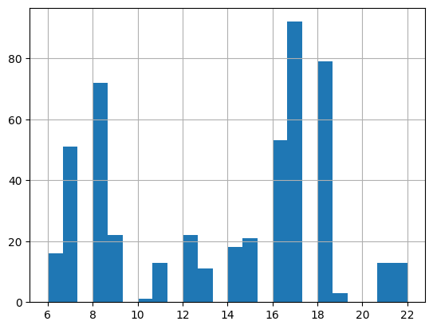

```python
# Visualize when the busiest times occur
df_sliced['hour'].hist(bins=24)
```

The chart show several peaks and you want to focus on the afternoon rush hour between 16:00 to 18:00.

**▶▶▶ Directions**

1. Filter `df_sliced` by two conditions: 'hour' should be greater than or equal to 16, and should be less than or equal to 18. Assign the result to the `df_filter_pm` variable.

```python
### START CODE HERE ###

# Filter `df_sliced` for 'hour' greater than or equal to 16, and less than or equal to 18.
df_filter_pm = df_sliced[(df_sliced["hour"]) >= 16 & (df_sliced["hour"] <= 18)]

### END CODE HERE ###

helper_functions.print_rows_stations(df_filter_pm)
```

```
number of rows: 500

stations in this DataFrame:
['Independencia.H' 'Bolivar' 'Pza. de los Virreyes' 'Catalinas'
 'Correo Central' 'General Belgrano' 'Avenida La Plata' 'Emilio Mitre'
 'Jose Maria Moreno' 'Retiro E' 'Boedo']
```

**Expected output:**

```
number of rows: 223

stations in this DataFrame:
['Bolivar' 'Independencia.H' 'Catalinas' 'Correo Central'
 'General Belgrano' 'Retiro E']
```

**Click here to see the solution**

Your solution should look something like this:

```
# Filter `df_sliced` for 'hour' greater than or equal to 16, and less than or equal to 18.
df_filter_pm = df_sliced[(df_sliced["hour"] >= 16) & (df_sliced["hour"] <= 18)]
```

**Congratulations for making it until the end of this lab. There is one more lab to go!**